# Rfssa: An R Package for Functional Singular Spectrum Analysis

Hossein Haghbin

Artificial Intelligence and Data Mining Research Group, ICT Research Institute

Jordan Trinka

Department of Mathematical and Statistical Sciences, Marquette University,

Mehdi Maadooliat

Department of Mathematical and Statistical Sciences, Marquette University,

2025-03-11

Abstract

Functional Singular Spectrum Analysis (FSSA) is a non-parametric approach for analyzing Functional Time Series (FTS) and Multivariate FTS (MFTS) data. This paper introduces Rfssa, an R package that addresses implementing FSSA for FTS and MFTS data types. Rfssa provides a flexible container, the funts class, for FTS/MFTS data observed on one-dimensional or multi-dimensional domains. It accepts arbitrary basis systems and offers powerful graphical tools for visualizing time-varying features and pattern changes. The package incorporates two forecasting algorithms for FTS data. Developed using object-oriented programming and Rcpp/RcppArmadillo, Rfssa ensures computational efficiency. The paper covers theoretical background, technical details, usage examples, and highlights potential applications of Rfssa.

## Introduction

In recent times, advancements in data acquisition techniques have made it possible to collect data in high-resolution formats. Due to the presence of temporal-spatial dependence, one may consider this type of data as *functional data*.

Functional Data Analysis (FDA) focuses on developing statistical methodologies for analyzing data represented as functions or curves. While FDA methods are particularly well-suited for handling smooth continuum data, they can also be adapted and extended to effectively analyze functional data that may not exhibit perfect smoothness, including high-resolution data and data with inherent variability.

The widely-used R package for FDA is [**fda**](https://CRAN.R-project.org/package=fda) (Ramsay et al. 2023), which is designed to support analysis of functional data, as described in the textbook by (Ramsay and Silverman 2005). Additionally, there are over 40 other R packages available on CRAN that incorporate functional data analysis, such as [**funFEM**](https://CRAN.R-project.org/package=funFEM) (Bouveyron 2021), [**fda.usc**](https://CRAN.R-project.org/package=fda.usc) (Febrero-Bandle and Fuente 2012), [**refund**](https://CRAN.R-project.org/package=refund) (Goldsmith et al. 2023), [**fdapace**](https://CRAN.R-project.org/package=fdapace) (Gajardo et al. 2022), [**funData**](https://CRAN.R-project.org/package=funData) (Happ-Kurz 2020), [**ftsspec**](https://CRAN.R-project.org/package=ftsspec) (Tavakoli 2015), [**rainbow**](https://CRAN.R-project.org/package=rainbow) (Shang and Hyndman 2022), and [**ftsa**](https://CRAN.R-project.org/package=ftsa) (Hyndman and Shang 2023).

One crucial initial requirement for any of these packages is to establish a framework for representing and storing infinite-dimensional functional observations. The [**fda**](https://CRAN.R-project.org/package=fda) package, for instance, employs the `fd` class as a container for functional data defined on a one-dimensional (1D) domain. An `fd` object represents functional data as a finite linear combination of known basis functions (e.g., Fourier, B-splines, etc.), storing both the basis functions and their respective coefficients for each curve. This representation aligns with the practical implementation found in many papers within the field of FDA. Conversely, several other R packages store functional data in a discrete form evaluated on grid points (e.g., [**fda.usc**](https://CRAN.R-project.org/package=fda.usc), [**refund**](https://CRAN.R-project.org/package=refund), [**funData**](https://CRAN.R-project.org/package=funData), [**rainbow**](https://CRAN.R-project.org/package=rainbow), and [**fdapace**](https://CRAN.R-project.org/package=fdapace)). These packages also provide the capability to analyze functions beyond the one-dimensional case, such as image data treated as two-dimensional (2D) functions (e.g., [**refund**](https://CRAN.R-project.org/package=refund), [**fdasrvf**](https://CRAN.R-project.org/package=fdasrvf), and [**funData**](https://CRAN.R-project.org/package=funData)). To the best of our knowledge, packages that support representation beyond 1D functions utilize the grid point representation for execution and storage.

Moreover, recent packages have been developed to handle multivariate functional data, which consist of more than one function per observation unit. Examples of such packages include [**roahd**](https://CRAN.R-project.org/package=roahd), [**fda.usc**](https://CRAN.R-project.org/package=fda.usc), and [**funData**](https://CRAN.R-project.org/package=funData).

The [**Rfssa**](https://CRAN.R-project.org/package=Rfssa) package was initially developed to implement FSSA for FTS, as discussed in the work of (Haghbin et al. 2021). FSSA extends Singular Spectrum Analysis (SSA), a model-free procedure commonly used to analyze time series data. The primary goal of SSA is to decompose the original series into a collection of interpretable components, such as slowly varying trends, oscillatory patterns, and structureless noise. Notably, SSA does not rely on restrictive assumptions like stationarity, linearity, or normality (Golyandina and Zhigljavsky 2013).

It’s worth noting that SSA finds applications beyond the functional framework, including smoothing and forecasting purposes (Hassani and Mahmoudvand 2013; Carvalho and Rua 2017). The non-functional version of FSSA, known as SSA, has previously been implemented in the [**Rssa**](https://CRAN.R-project.org/package=Rssa) package (Golyandina et al. 2015) and the [**ASSA**](https://CRAN.R-project.org/package=ASSA) package (Carvalho and Martos 2020).

The [**Rssa**](https://CRAN.R-project.org/package=Rssa) package provides various visualization tools to facilitate the grouping stage, and the [**Rfssa**](https://CRAN.R-project.org/package=Rfssa) package includes equivalent functional versions of those tools (Golyandina, Korobeynikov, and Zhigljavsky 2018). While the foundational theory of FSSA was originally designed for univariate FTS, it has since been extended to handle multidimensional FTS data, referred to as Multivariate FSSA (MFSSA) (Jordan Trinka, Haghbin, and Maadooliat 2022). Furthermore, in line with the developments in SSA for forecasting, two distinct algorithms known as Recurrent Forecasting (FSSA R-forecasting) and Vector Forecasting (FSSA V-forecasting) were introduced for FSSA by (J. Trinka et al. 2023). Both of these forecasting algorithms, along with the capabilities for handling MFSSA, have been seamlessly integrated into the most recent version of the [**Rfssa**](https://CRAN.R-project.org/package=Rfssa) package.

The remainder of this manuscript is organized as follows. Section 2 introduces the FTS/MFTS data preparation theory used in the `funts` class. Section 3 discusses the FSSA methodology, including the basic schema of FSSA, FSSA R-forecasting, and FSSA V-forecasting. Technical details of the [**Rfssa**](https://CRAN.R-project.org/package=Rfssa) package are provided in Section 4, where we describe the available classes in the package and illustrate their practical usage with examples of real data. Section 5 focuses on the reconstruction stage and FSSA/MFSSA forecasting. In Section 6, we provide a summary of the embedded shiny app. Finally, we conclude the paper in Section 7.

## Data preparation in FTS

Define $\textbf{y}_N=(y_1,\ldots,y_N)$ to be a collection of observations from an FTS. In the theory of FTS, $y_i$’s are considered as functions in the space $\mathbb{H}=L^2(\mathcal{T})$ where $\mathcal{T}$ is a compact subset of $\mathbb{R}.$ Let $s\in\mathcal{T}$ and consider $y_i(s)\in\mathbb{R}^p$, the sequence of $\textbf{y}_N$ is called (univariate) FTS if $p=1$, and multivariate FTS (or MFTS) if $p>1.$

In the realm of functional data analysis, we operate under the assumption that the underlying sample functions, denoted as $y_{i}(\cdot)$, exhibit smoothness for each sample $i$, where $i=1, \ldots, N$. Nevertheless, in practical scenarios, observations are typically acquired discretely at a set of grid points and are susceptible to contamination by random noise. This phenomenon can be represented as follows:

$$Y_{i,k} = y_{i}(t_k) +\varepsilon_{i,k}, \quad k=1,\ldots,
K. (\#eq:discr-data)$$

In this expression, $t_k\in\mathcal{T}$, and $K$ denotes the count of discrete grid points across all samples. The $\varepsilon_{i,k}$ terms represent i.i.d. random noise.

To preprocess the raw data, it is customary to employ smoothing techniques, converting the discrete observations $Y_{i,k}$ into a continuous form, $y_{i}(\cdot)$. This is typically performed individually for each variable and sample. One widely used approach is finite basis function expansion (Ramsay and Silverman 2005). In this method, a set of basis functions $\left\lbrace \nu_i \right\rbrace_{ i\in\mathbb{N}}$ is considered (not necessarily orthogonal) for the function space $\mathbb{H}$. Each sample function $y_{i}(\cdot)$ in @ref(eq:discr-data) is then considered as a finite linear combination of the first $d$ basis functions:

$$y_i(s)= \sum_{j=1}^d c_{ij}\nu_j(s). (\#eq:basis-expan)$$

Subsequently, the coefficients $c_{ij}$ can be estimated using least square techniques. By adopting the linear representation form for the functional data in @ref(eq:basis-expan), we establish a correspondence between each function $y_i(\cdot)$ and its coefficient vector ${\pmb c}_i=(c_{ij})_{j=1}^d.$ As a result, the coefficient vectors ${\pmb c}_i$ can serve to store and retrieve the original functions, $y_i(\cdot)$’s. This arises from the inherent isomorphism between two finite vector spaces of the same dimension (in this case, $d$). Consequently, ${\pmb c}_i$’s are stored as the primary attribute of `funts` objects within the [**Rfssa**](https://CRAN.R-project.org/package=Rfssa) package.

Take two elements $x, y\in \mathbb{H}$ with corresponding coefficient vectors ${\pmb c}_x$ and ${\pmb c}_y.$ Then, the inner product of $x, y$ can be computed in matrix form as $\langle x,y \rangle={\pmb c}_x^\top \mathbf{G} {\pmb c}_y$, where $\mathbf{G}=[ \langle \nu_i,\nu_j \rangle ]_{i,j=1}^{d}$ is the Gram matrix.

It is important to note that $\mathbf{G}$ is Hermitian. Furthermore, because the basis functions $\{\nu_i\}_{i=1}^d$ are linearly independent, $\mathbf{G}$ is positive definite, making it invertible (Horn and Johnson 2012 Thm. 7.2.10).

Moreover, let $A:\mathbb{H}\rightarrow \mathbb{H}$ be a linear operator and $y=A(x).$ Then, ${\pmb c}_y= \mathbf{G}^{-1}\mathbf{A}{\pmb c}_x,$ where $\mathbf{A}=[ \langle A(\nu_j),\nu_i \rangle ]_{i,j=1}^{d}$ is called the corresponding matrix of the operator $A.$

It is worth noting that while the FSSA theory extends to arbitrary dimensions, practical implementation for dimensions greater than $2$ introduces considerable computational complexity. Moreover, high-dimensional FTS data are relatively rare in real-world applications. Therefore, within the [**Rfssa**](https://CRAN.R-project.org/package=Rfssa) package, we have chosen to confine the `funts` object to support functions observed over domains that are one or two-dimensional. In the [**Rfssa**](https://CRAN.R-project.org/package=Rfssa) package, the task of preprocessing the raw discrete observations and converting those to the `funts` object is assigned to the `funts(`$\cdot$`)` constructor.

## An overview of the FSSA methodology

FSSA is a nonparametric technique to decompose FTS and MFTS, and the methodology can also be used to forecast such data (Haghbin et al. 2021; Jordan Trinka, Haghbin, and Maadooliat 2022; J. Trinka et al. 2023); it can also be used as a visualization tool to illustrate the concept of seasonality and periodicity in the functional space over time.

### Basic schema of FSSA

Basic FSSA consists of two stages where each stage includes two steps. We outline the four steps of the FSSA algorithm here.

- **First stage: decomposition**
  - *Embedding*
    For a positive integer, $L<N/2$, let $\mathbb{H}^L$ be the Cartesian product of $L$ copies of $\mathbb{H}$ and define the *trajectory* operator $\mathbfcal{X}:\mathbb{R}^{K} \rightarrow \mathbb{H}^{L}$ with
    $$\label{trajectory}
    \mathbfcal{X}{\pmb a}:=\sum_{j=1}^K a_j{\pmb x}_j,\qquad
    \ {\pmb a}=\left(a_1,\ldots, a_K\right)^\top
    \in\mathbb{R}^K. (\#eq:trajectory)$$

    where $K=N-L+1$ and
    $$\label{flvec}
    {\pmb x}_j(s):= \left( y_j(s), y_{j+1}(s), \ldots,
    y_{j+L-1}(s)\right)^\top,\ j=1,\ldots, K, (\#eq:flvec)$$
    are called *lag-vectors*. One may consider the trajectory operator $\mathbfcal{X}$ in @ref(eq:trajectory) as an $L \times K$ matrix with functional entries in the form of
    $$\label{eqn:hankelmat}
    \mathbfcal{X}(s) = \begin{bmatrix}y_{1}(s) & y_{2}(s) &
    y_{3}(s) & \cdots & y_{K}(s) \\ y_{2}(s) & y_{3}(s) &
    y_{4}(s) & \cdots & y_{K+1}(s) \\ y_{3}(s) & y_{4}(s) &
    y_{5}(s) & \cdots & y_{K+2}(s) \\ \vdots & \vdots &
    \vdots & \ddots & \vdots \\ y_{L}(s) & y_{L+1}(s) &
    y_{L+2}(s) & \cdots &
    y_{N}(s) \end{bmatrix}. (\#eq:eqnhankelmat)$$

    Note that the antidiagonal elements of the matrix in @ref(eq:eqnhankelmat) are all equal. Such matrices are called Hankel, and since $\mathbfcal{X}(s)$ is a Hankel matrix for any $s$ in the domain, we call $\mathbfcal{X}$ a Hankel operator. In practice, a main challenge is how to use the original basis of $\mathbb{H}$ to represent the lag-vectors in $\mathbb{H}^L$. To do this, one may define a quotient sequence $q_k$, and a reminder sequence $r_k$, by $k=(q_k-1)L+r_k,$ where $1\leq r_k\leq L$, and $1\leq q_k\leq d$. Now, consider ${\pmb \phi}_{k}$ as a functional vector of length $L$ with all zero functions, except $r_k$-th element, which is $\nu_{q_k}$. Using this definition, the lag-vector ${\pmb{x}_j}$ given in @ref(eq:flvec) can be represented as a linear combination of $\{{\pmb \phi}_{k}\}_{k=1}^{Ld}$ with the corresponding coefficient vector ${\bf b}_j=(c_{1j},\ldots, c_{1,j+L-1},c_{2j},\ldots,c_{2,j+L-1},\ldots,c_{d,j+L-1} )^\top.$
  - *FSVD*
    We apply the functional singular value decomposition (FSVD) to $\mathbfcal{X}$ and obtain a collection of singular values, $\{\sqrt{\lambda_i}\}_{i=1}^{r}$, orthonormal right singular vectors $\{\mathbf{v}_{i}\}_{i=1}^{r}$ (that are elements of $\mathbb{R}^{K}$), and orthonormal left singular functions $\{\pmb{\psi}_{i}\}_{i=1}^{r}$ (that are elements of $\mathbb{H}^{L}$). The collection $(\sqrt{\lambda_i}, \pmb{\psi}_i, \mathbf{v}_i)$ will be called the $i^{th}$ eigentriple of the FSVD, and $r$ is the rank of $\mathbfcal{X}$:
    $$\label{FSVD}
    \mathbfcal{X} = \sum_{i=1}^{r} \mathbfcal{X}_{i} =
    \sum_{i=1}^{r} \sqrt{\lambda_i} \mathbf{v}_{i} \otimes
    \pmb{\psi}_{i}, (\#eq:FSVD)$$
    where $\mathbfcal{X}_{i}:\mathbb{R}^{K} \rightarrow \mathbb{H}^{L}$ is a rank one elementary operator. To implement the FSVD of $\mathbfcal{X}$ given in @ref(eq:FSVD), let ${\bf B}:=[{\bf b}_1,\cdots,{\bf b}_K]$, $\mathbf{G}:=[ \langle {\pmb \phi}_{i}, {\pmb \phi}_{j} \rangle_{\mathbb{H}^L}]_{i,j=1}^{Ld}$, $\mathbf{X}:=\mathbf{G}^{1/2}\mathbf{B}$, and $\left(\sqrt{\lambda_i}, \pmb{u}_i, \mathbf{v}_i\right)$’s be the eigentriples of the SVD of the matrix $\mathbf{X}$. It can be shown that $\left(\sqrt{\lambda_i},\pmb{\psi}_i,\mathbf{v}_i \right)$ is the $i^{th}$ eigentriple of the FSVD of $\mathbfcal{X}$, where the left singular function, ${\pmb \psi}_i$, is corresponding to the coefficient vector $\mathbf{G}^{-1/2}{\pmb u}_i$. See (Haghbin et al. 2021) for more details.

  These steps can also be extended to multivariate case, i.e. MFSSA. See (Jordan Trinka, Haghbin, and Maadooliat 2022) for more details. In the [**Rfssa**](https://CRAN.R-project.org/package=Rfssa) package, the results of the decomposition stage is held in an object from the `fssa` class. The constructor, `fssa(`$\cdot$`)`, performs the decomposition for both FSSA and MFSSA algorithm and returns an object of class `fssa`. Further discussion about the attributes and methods of the `fssa` class is given in the technical details section.
- **Second stage: reconstruction**
  - *Grouping*
    We partition the set of indices $\{1,\dots,r\}$ into disjoint sets $I_{q}$, where $q \in \{1,\dots, m\}$ and $m\leq r$. From here, we obtain the group $\mathbfcal{X}_{I_{q}}$ by combining the respective elementary operators accordingly:
    $$\mathbfcal{X}_{I_{q}} = \sum_{i \in I_{q}}
    \mathbfcal{X}_{i}. \nonumber$$
    Exploratory plots of singular values, right singular vectors, and left singular functions that investigate the different modes of variation extracted in the decomposition stage are used to decide how to form the sets, $I_{q}$, and we discuss such plots in further detail in section five.
  - *Hankelization*  
    Since each $\mathbfcal{X}_{I_{q}}$ is not necessarily Hankel, we perform diagonal averaging of the entries to Hankelize each operator. From each Hankelized $\mathbfcal{X}_{I_{q}}$, we obtain an FTS, $\mathbf{y}_{N}^{q}$, that describes main characteristics of $\mathbf{y}_{N}$ such as mean, seasonal, trend, and noise behaviors.

  For the reconstruction stage, the [**Rfssa**](https://CRAN.R-project.org/package=Rfssa) package provides the function `freconstruct(`$\cdot$`)` which returns a list of objects of class `funts` associated to the groups specified by the user. If the supplied input to the `fssa(`$\cdot$`)` function is an MFTS, the signal extraction process is almost identical as compared to the univariate case with the exception that now, we have that each element of the time series is a tuple of functions comprised of elements observed over one or two-dimensional domains.

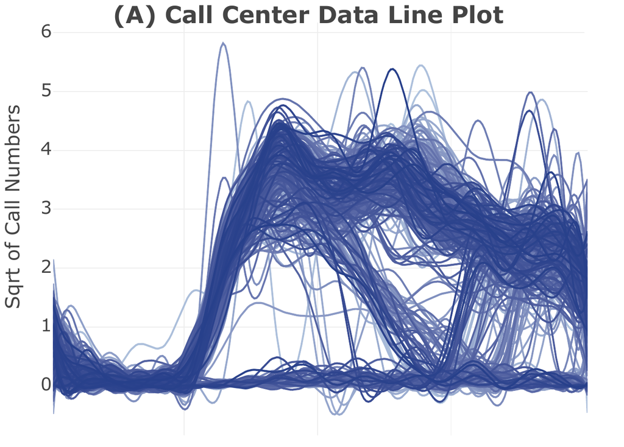

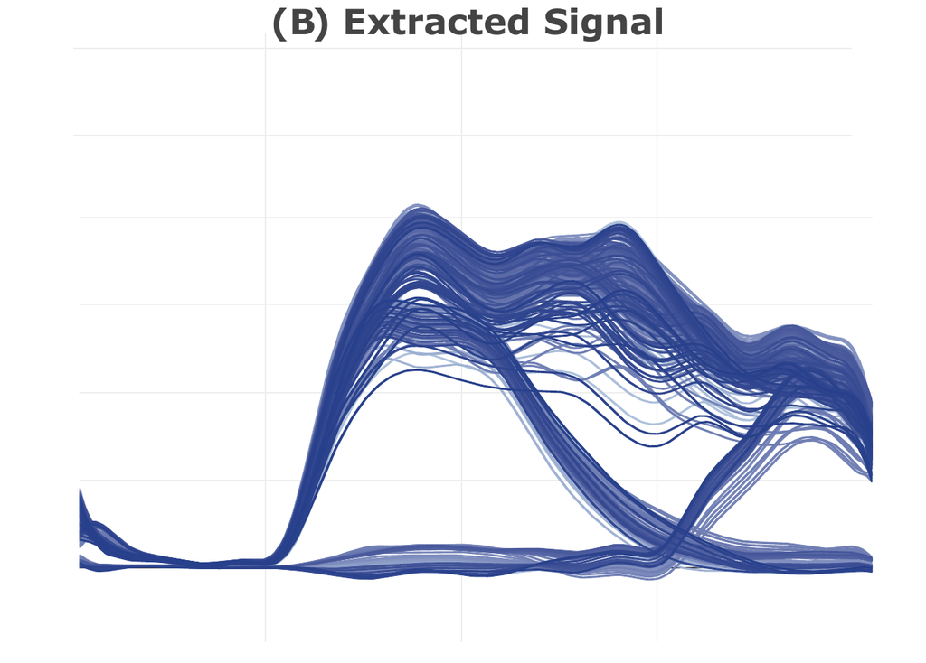

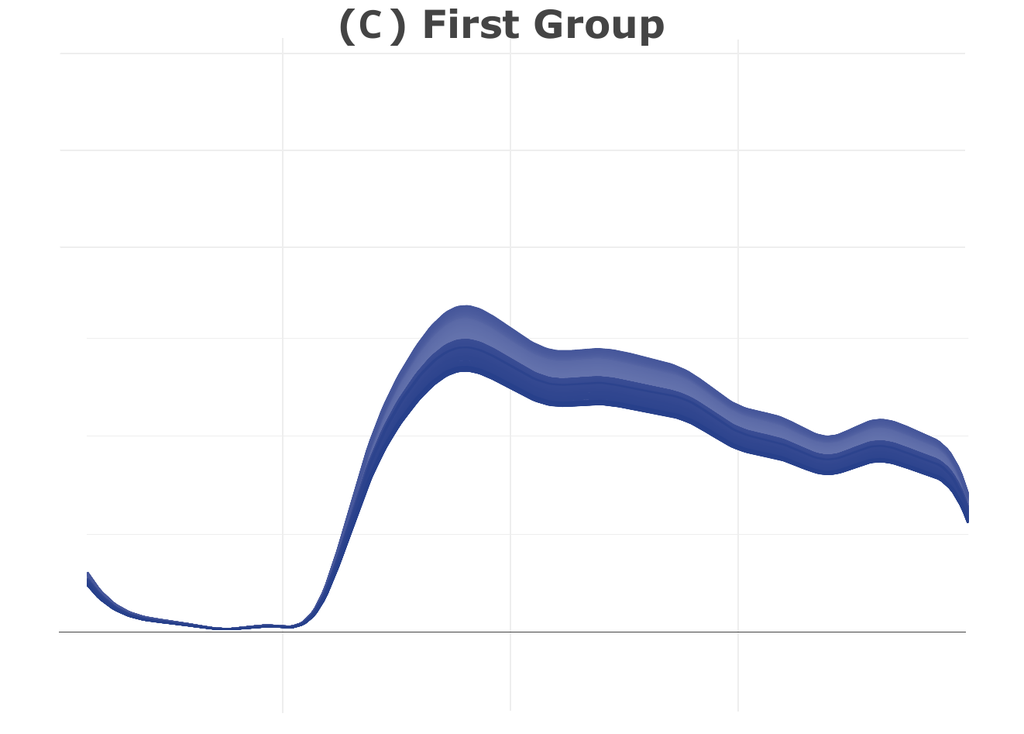

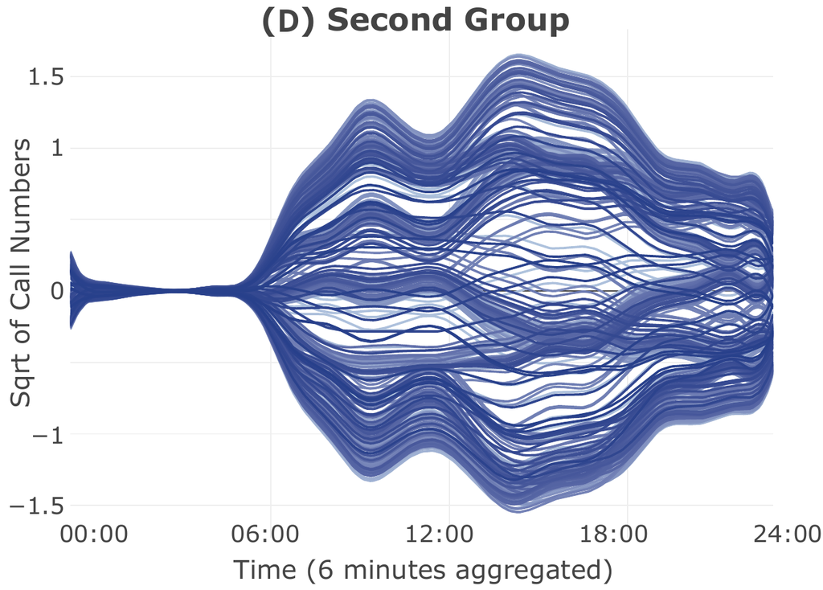

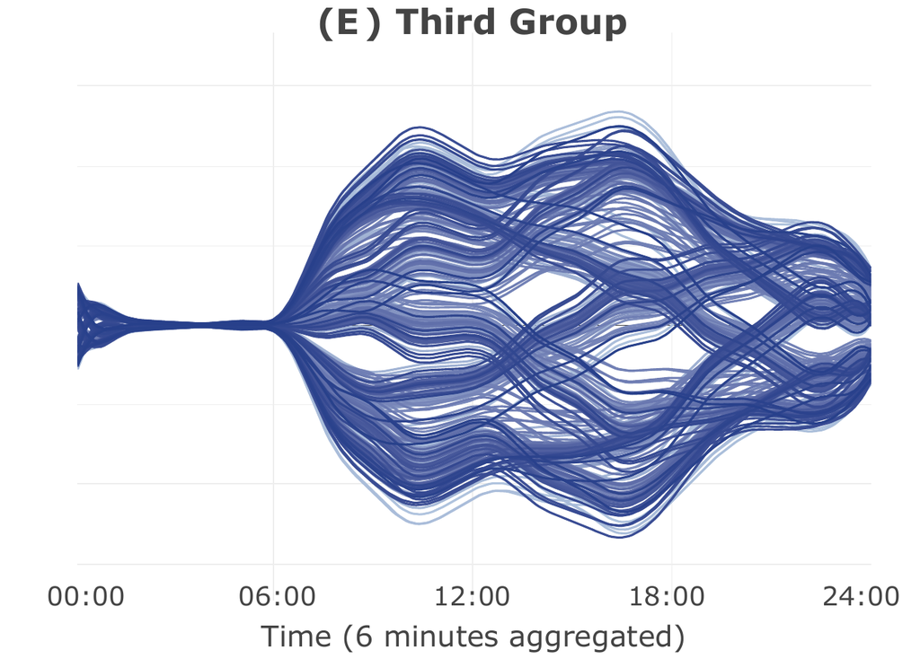

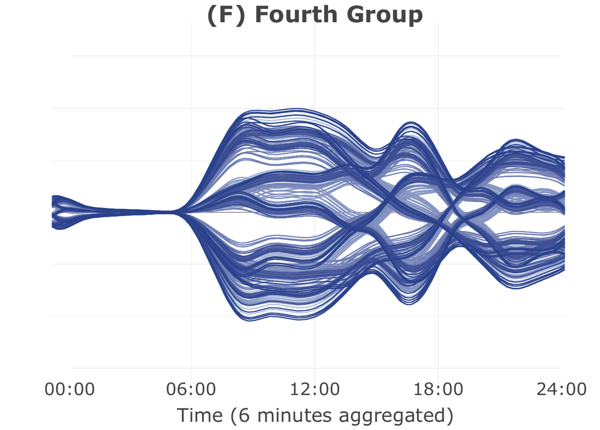

(A): Line plot of Callcenter data; (B): FTS reconstructed using $I_{\mathfrak{s}} = \{1,\cdots,7\}$; (C): FTS reconstructed by setting $I_{1}=\{1\}$; (D): FTS reconstructed using $I_{2} = \{2,3\}$; (E): FTS reconstructed from $I_{3}=\{4,5\}$; (F): FTS reconstructed from $I_{4}=\{6,7\}$.

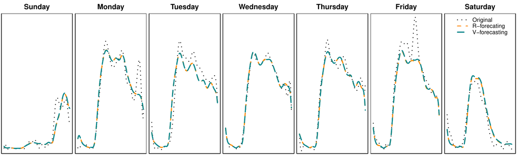

The prediction of the last 7 days of the year 1999 for the Callcenter data, based on FSSA R-forecasting and V-forceasting, and comparing the results with the observed functions.

### FSSA Forecasting

After the decomposition stage, one may perform forecasting instead of reconstruction (Figure @ref(fig:figroadpap)). R-forecasting and V-forecasting are two main defined approaches in FSSA/MFSSA (J. Trinka et al. 2023). In both forecasting methods, the goal is to obtain the FTS, $\mathbf{g}_{N+M}^{q}=\left(g_{1}^{q},\dots,g_{N+M}^{q}\right)$, where the first $N$ terms are close to $\mathbf{y}_{N}^{q}$ and the goal is to forecast the remaining elements, $\{g_{i}^{q}\}_{i=N+1}^{N+M}$.

Forecasts in the R-forecasting method, are obtained using a linear combination of the previous $L-1$ elements of $\mathbf{g}_{N+M}^{q}$. Consider a positive integer $k<r$ and define $\mathbfcal{V} = \sum_{i=1}^{k} \pi_{i} \otimes \pi_{i}$, where $\pi_{i} \in \mathbb{H}$ is the last element of left singular function $\pmb{\psi}_{i}$. Define $\mathbfcal{A}_{j}: \mathbb{H} \rightarrow \mathbb{H}$ such that $\mathbfcal{A}_{j} = \sum_{i=1}^{k}\psi_{j,i} \otimes \left(\mathbfcal{I} - \mathbfcal{V}\right)^{-1}\pi_{i}$, where $\psi_{j,i}$ is the $j^{\text{th}}$ component of $\pmb{\psi}_{i}$, and $\mathbfcal{I}:\mathbb{H} \rightarrow \mathbb{H}$ is the identity operator. Then the R-forecasting can be obtained using following equation
$$g_{i}^{q}=\begin{cases}
y_{i}^{q}, & i=1,\dots,N \\
\sum_{j=1}^{L-1}\mathbfcal{A}_{j}g_{i+j-L}^{q}, &
i=N+1,\dots,N+M.
\end{cases}$$

Forecasts in the V-forecasting method, are obtained by predicting functional vectors. One may define an orthogonal projection, $\pmb{\Pi}:\mathbb{H}^{L-1} \rightarrow \mathbb{H}^{L-1}$, that projects onto the space spanned by $\{\pmb{\psi}_{i}^{\nabla}\}_{i=1}^{k}$, where $\pmb{\psi}_{i}^{\nabla} \in \mathbb{H}^{L-1}$ is formed from the first $L-1$ elements of $\pmb{\psi}_{i}$. Now let $\mathbfcal{Q}:\mathbb{H}^{L} \rightarrow \mathbb{H}^{L}$ be given by
$$\mathbfcal{Q}\left(\pmb{x}\right)=\begin{pmatrix}
\pmb{\Pi}\left(\pmb{x}^{\Delta}\right) \\
\sum_{j=1}^{L-1}\mathbfcal{A}_{j}x^{\Delta}_{j}\end{pmatrix}, \qquad
{\pmb{x}} \in \mathbb{H}^{L} \nonumber,$$
where $\pmb{x}^{\Delta}$ contains the last $L-1$ components of $\pmb{x}$, and $x_{j}^{\Delta}$ is the $j^{\text{th}}$ component of $\pmb{x}^{\Delta}$. The V-forecasting algorithm is given in the following steps:

1. Define $\pmb{w}^{q}_{j}$ as
   $$\pmb{w}^{q}_{j}= \begin{cases}
   \pmb{x}^{q}_{j}, & j=1,\dots, K \\
   \mathbfcal{Q}\pmb{w}^{q}_{j-1}, & j=K+1, \dots, K+M,
   \end{cases}$$
   where $\{\pmb{x}^{q}_{j}\}_{j=1}^{K}$ spans the range of operator $\mathbfcal{X}_{I_{q}}$.
2. Form the operator $\mathbfcal{W}^q:\mathbb{R}^{K+M} \rightarrow \mathbb{H}^{L}$ whose range is linearly spanned by the set $\{\pmb{w}_{i}^q\}_{i=1}^{K+M}$.
3. Hankelize $\mathbfcal{W}^q$ in order to extract the FTS $\mathbf{g}^{q}_{N+M}$.
4. The functions, $g^{q}_{N+1}, \dots, g^{q}_{N+M}$, form the $M$ terms of the FSSA vector forecast.

Continuing from the previous example, we utilized the first 358 days of the year to train the FSSA model on the `Callcenter` dataset. Subsequently, we employed the FSSA R-forecasting and V-forecasting methods to make predictions for the final week ($len = 7$). Figure @ref(fig:figfor-call) illustrates both the actual and forecasted curves for each day of the week, employing each respective method. Detailed code for this process can be found in the subsequent sections.

In the [**Rfssa**](https://CRAN.R-project.org/package=Rfssa) package, we offer the `fforecast(`$\cdot$`)` function designed for the execution of R-forecasting or V-forecasting algorithms. This function expects an input argument of class `fssa` and yields an output of class `fforecast`. The latter comprises a list of objects of class `funts`, with each `funts` representing a forecasted group.

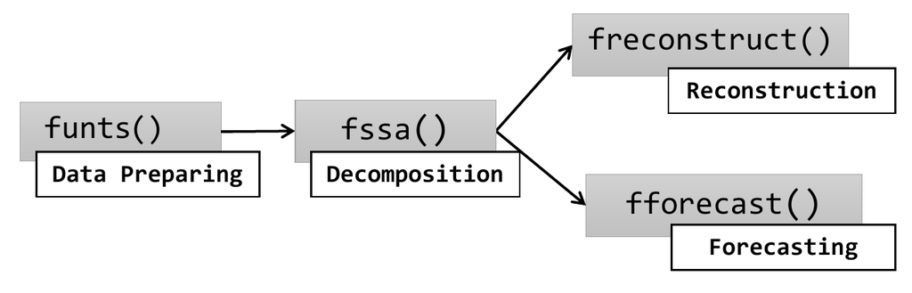

The roadmap of the Rfssa package.

## Technical details of the Rfssa package

The roadmap of the main functions used in the [**Rfssa**](https://CRAN.R-project.org/package=Rfssa) package is given in Figure @ref(fig:figroadpap). The inputs and outputs of these functions are described in Table 1. As it can be seen from Table 1, three classes (`funts`, `fssa` and `fforecast`) are used to support the return objects of theses functions. The `funts(`$\cdot$`)`, `fssa(`$\cdot$`)` and `fforecast(`$\cdot$`)` functions are the constructors of the `funts`, `fssa` and `fforecast` classes, respectively. In the rest of this section we present these classes with illustrative examples, and later we describe the reconstruction and forecasting functions in details.

Table 1: A summary of FSSA written functions in the [**Rfssa**](https://CRAN.R-project.org/package=Rfssa) package.

| Function | Descriptions |  | Returns |
| --- | --- | --- | --- |
| `funts(`$\cdot$`)` | Create FTS/MFTS objects | Discretely sampled data or coefficients, basis system specifications, a set of argument values corresponding to the observations in X, the time specifications arguments. | An object of class `funts`. |
| `fssa(`$\cdot$`)` | Performs the decomposition (including embedding and FSVD steps) stage for FTS/MFTS data. | An object of class `funts` and window length $L.$ | An object of class `fssa`. |
| `freconstruct(`$\cdot$`)` | Performs the reconstruction (including grouping and Hankelization steps) stage. | An object of class `fssa` and list of numeric vectors includes indices of elementary components of a group. | A list of `funts` objects reconstructed according to the specified groups. |
| `fforecast(`$\cdot$`)` | Performs FSSA R-forecasting or FSSA V-forecasting. | An object of class `fssa`, list of numeric vectors includes indices of elementary components of a group used for reconstruction and forecasting and forecast horizon $h$. | An object of class `fforecast`. |

### The `funts` class

The `funts(`$\cdot$`)` constructor is used to create an `S3` object of class `funts`. This object is designed to encapsulate various forms of FTS, including both univariate and multivariate types. It offers a versatile framework for the creation and manipulation of `funts` objects, accommodating different basis systems and dimensions. It accepts the following arguments:

- `X`: A matrix, three-dimensional array, or a list of matrix or array objects. When `method="data"`, it represents the observed curve values at discrete sampling points or argument values. When `method="coefs"`, `X` specifies the coefficients corresponding to the basis system defined in `basisobj`. If `X` is a list, it defines a multivariate FTS, with each element being a matrix or three-dimensional array object. In matrix objects, rows correspond to argument values, and columns correspond to the length of the FTS. In three-dimensional array objects, the first and second dimensions correspond to argument values, and the third dimension to the length of the FTS.
- `basisobj`: This argument should be an object of class `basisfd`, a matrix of empirical basis, or a list of `basisfd` or empirical basis objects. In the case of empirical basis, rows correspond to basis functions, and columns correspond to grid points.
- `argval`: A vector list of length `p`, representing a set of argument values corresponding to the observations in `X`. Each entry in this list should either be a numeric value or a list of numeric elements, depending on the dimension of the domain over which the variable is observed. It’s worth noting that these values can vary from one variable to another. If `argval` is set to `NULL`, the default values are the integers from 1 to *n*, where *n* is the size of the first dimension in the `X` argument.
- `method`: This parameter determines the type of the `X` matrix, and it can take one of two values: `coefs` or `data`.
- `start` and `end`: Specify time of the first and last observations. They can be a single positive integer or an object of classes `Date`, `POSIXct`, or `POSIXt`, representing a natural time unit.
- `tname`, `vnames` and `dnames`: These parameters accept strings or lists of strings to specify the names of time, variables, and domains.

The `funts(`$\cdot$`)` constructor offers flexibility to users. Users can either provide their custom basis or request [**Rfssa**](https://CRAN.R-project.org/package=Rfssa) to generate the basis for them, leveraging the capabilities of the [**fda**](https://CRAN.R-project.org/package=fda) package. It is assumed that each variable is observed over a regular and equidistant grid. Furthermore, each variable in the `funts` object is assumed to be observed over either a one or two-dimensional domain, as illustrated in Figure @ref(fig:figfts). To enhance the representation of time, the `funts` function introduces two parameters, namely `start` and `end`, which capture the time series duration. This design allows users to specify time information in a structured and standardized manner. Users have the flexibility to set `start` and `end` using various time and date classes, such as `Date`, `POSIXct`, or `POSIXt`. If users do not provide the `start` and `end` arguments, default values are used, with `start=1` and `end=N`, where $N$ represents the length of the time series. This default approach aligns with common practices, as seen in classes like `ts` in the [**stats**](https://CRAN.R-project.org/package=stats) package, as well as `fts` classes in [**rainbow**](https://CRAN.R-project.org/package=rainbow) or [**ftsa**](https://CRAN.R-project.org/package=ftsa). An object of class `funts` is a list encompassing the following elements:

1. `N`: Represents the length of the time series.
2. `dimSupp`: A list specifying the dimensions of the support domain of the variables.
3. `time`: The time object.
4. `coefs`: A list containing basis coefficients.
5. `basis`: A list of basis systems.
6. `B_mat`: Evaluated basis functions on initial arguments.
7. `argval`: Initial arguments of the observed functions.

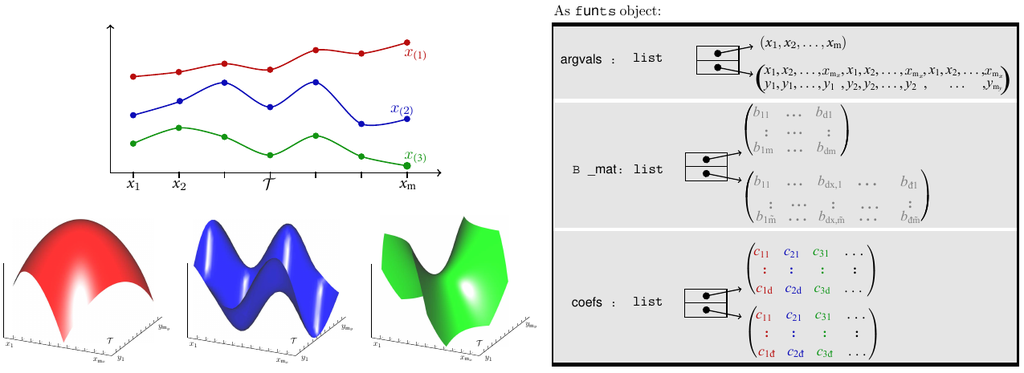

The main roadmap of funts objects.

The `funts` class provides essential functionalities for managing FTS objects, ensuring users have well-defined basic operations. It supports arithmetic operations like addition and multiplication, along with indexing methods. Additionally, three generic methods, `length(`$\cdot$`)`, `print(`$\cdot$`)`, and `plot(`$\cdot$`)`, are available. The `eval.funts(`$\cdot$`)` method allows users to evaluate a `funts` object on a specified grid. To determine if an object belongs to the `funts` class, the `is.funts(`$\cdot$`)` method is provided. Converting objects from the [**fda**](https://CRAN.R-project.org/package=fda) package’s `fd` class or the [**rainbow**](https://CRAN.R-project.org/package=rainbow) package’s `fts` class to a `funts` object is made easy using the `as.funts(`$\cdot$`)` function. The strength of `funts` objects lies in their powerful visualization capabilities within the field of FTS. Users can create two types of plots using the graphical commands `plot(`$\cdot$`)` and `plotly_funts(`$\cdot$`)`. The `plot(`$\cdot$`)` method utilizes base graphics objects to generate FTS plots. On the other hand, the `plotly_funts(`$\cdot$`)` function offers a versatile [**plotly**](https://CRAN.R-project.org/package=plotly) platform for visualizing FTS data, providing several plot types: `line`, `3Dline`, `3Dsurface`, and `heatmap`. These plots making it easier to detect trends or patterns within each curve’s behavior over time. Furthermore, users can directly apply `plotly_funts(`$\cdot$`)` function to objects from the `fd`, `fds`, or `fts` classes in packages like [**rainbow**](https://CRAN.R-project.org/package=rainbow), [**fds**](https://CRAN.R-project.org/package=fds), [**ftsa**](https://CRAN.R-project.org/package=ftsa), or [**fda**](https://CRAN.R-project.org/package=fda), without the need for conversion to `funts` objects. Additionally, when converting objects from packages like `fds` or `fts`, the `xname` and `yname` arguments are automatically captured and used as the `xlab` and `zlab` arguments, ensuring that resulting plots are informative and intuitive.

To demonstrate the capabilities of the [**Rfssa**](https://CRAN.R-project.org/package=Rfssa) package for handling FTS, two illustrative examples are provided. The first example showcases the `Callcenter` dataset consisting of curves observed over a one-dimensional domain. In contrast, the second example involves a bivariate FTS dataset, which includes a sequence of two types of remote sensing images (two-dimensional functional data domain).